# Lab: GORIC(A) Evidence Synthesis

## 1.2 Exercise 1b

- Do the same as in Exercise 1a for the data of Chandler (2015) - contained in the file C.txt. Btw, make sure to save the dataset in your working directory.
- The report by Chandler (2015) is also contained in the lab materials (“Ex2r Chandler_final.docx”).

**Click to see answers**

```r
### Replication of the JU study: C

# Read in data
C <- read.table("C.txt", header = TRUE)

C$g <- factor(C$g)
# this command tells R that 'g' is a factor and not a continuous variable like
# 'at'

## Inspect data head(C)

## Compute descriptives for each group descrip <- describeBy(C$z,C$g,mat=TRUE)
## print(descrip)


# lm object (of ANOVA model)
lm_fit_C <- lm(z ~ g - 1, data = C)

# Check names used in model
names(coef(lm_fit_C))
```

```
[1] "gph" "gpl" "grh" "grl"
```

```r
# Specify restrictions using those names


# Hypotheses Set
H1_C <- "grh > gph > grl > gpl"
H2_C <- "grh > gph = grl > gpl"
# Note, these are used as competing hypotheses.


# Calculate GORIC values and weights
set.seed(123)  # Set seed value
goric_C <- goric(lm_fit_C, hypotheses = list(H1_C = H1_C, H2_C = H2_C))
goric_C
```

```
restriktor (0.7): generalized order-restricted information criterion:

Results:
           model   loglik  penalty    goric  loglik.weights  penalty.weights  goric.weights  goric.weights_without_unc
1           H1_C  -42.888    3.083   91.942           0.500            0.424          0.872                      1.000
2           H2_C  -51.340    2.892  108.464           0.000            0.514          0.000                      0.000
3  unconstrained  -42.888    5.000   95.775           0.500            0.062          0.128

Conclusion:
- The order-restricted hypothesis 'H1_C' is the best in the set, as it has the highest GORIC(A) weight.
- Since 'H1_C' has a higher GORIC(A) weight than the unconstrained hypothesis, it is not considered weak. We can now inspect the relative support for 'H1_C' against the other order-restricted hypotheses:
  * 'H1_C' is 3.870e+03 times more supported than 'H2_C'.
```

```r
# summary(goric_C)
```

*Conclusion:*

H1_C is not a weak hypothesis, since its support is stronger than the support for the unconstrained. Since at least one of the competing hypotheses is not weak, one can compare their support.

## 1.3 Exercise 1c

In Exercises 1a and 1b, you found the study-specific support for the central theory. In this exercise, you will aggregate this using the `evSyn` function (with the added-evidence approach).

**Click to see answers**

```r
# GORICA Evidence synthesis #

# There are several input options. Next, two are given.
# Both/All will of course render the same output.
#
# 1) Input: goric objects
GORIC_studies <- list(goric_JU, goric_C)
# Evidence synthesis (the added-evidence approach)
evSyn_anchor <- evSyn(GORIC_studies,
                      hypo_names = goric_JU$result[,1]
                      #type_ev = "added" # default
                      )
# Notes:
# - In the case of goric objects, the type of IC (here, goric (thus GORIC)) is known.
# - Since hypothesis names can differ per goric object, one should assign them in evSyn;
#   if not, then by default the hypotheses are called H1, H2, etc.
#
# 2) Input: IC values
# In this case, we obtain them by extracting GORIC values from the studies:
GORIC_studies <- list(goric_JU$result[,4], goric_C$result[,4])
# Evidence synthesis (the added-evidence approach)
evSyn_anchor <- evSyn(GORIC_studies,
                      type = "goric",
                      hypo_names = goric_JU$result[,1]
                      #type_ev = "added" # default
                      )
# Note: By denoting the type, the output will say GORIC instead of GORICA.
#
# More notes: With this input, you do not obtain output regarding log-likelihood values and weights.
# For that, one needs to use, for example, the 'LL & PT' as input or the goric objects themselves;
# see other examples and/or 'Tutorial_GORIC_restriktor_evSyn' on https://github.com/rebeccakuiper/Tutorials.

# Show output
evSyn_anchor
```

```
restriktor (0.7): added Evidence Synthesis results:

Input type 'icvalues' detected: Information criteria values

---

Final GORIC weights:
               GORIC weights
H1_JU                  0.979
H2_JU               1.01e-04
unconstrained          0.021

---

Ratio final GORIC weights:
               vs. H1_JU  vs. H2_JU  vs. unconstrained
H1_JU              1.000   9.68e+03             45.964
H2_JU           1.03e-04      1.000              0.005
unconstrained      0.022    210.614              1.000
```

```r
# Final ratios of GORICA weights:
#round(evSyn_anchor$Final_ratio_GORICA_weights, 2)
# Study-specific and final/overall output:
#summary(evSyn_anchor)
# Study-specific GORICA weights:
#evSyn_anchor$GORICA_weight_m
# evSyn plot:
#plot(evSyn_anchor)
```

*Conclusion:*

When aggregating the results, we find (perhaps unsurprisingly) that ‘H1’ is the best (and thus not weak).

# 2 Exercise 2: Aggregating evidence from two studies

*Intro*  
- Imagine that you are in a group (unbeknownst to you, all the others in the group are actors) and that the atmosphere in the group is that criminal behavior is linked to having an African American background.  
- You publicly have to rate your attraction to a person in a video.  
- This is repeated using the same group of actors with you replaced by another person, that is, there are more participants in the experiment that have to rate the attraction to a person in a video.  
- There are three experimental conditions:

*Three conditions:*  
- Condition 1: participants rate the attraction to a person that is ‘obedient’, that is, a person who selects an African American from a police line up of three.  
- Condition 2: participants rate a moral rebel (i.e., a person not selecting an African American) after executing a self-affirmation task intended to boost their self-confidence.  
- Condition 3: participants rate a moral rebel after executing a bogus writing task.

*Two studies:*  
- 1st study: Explore & Obtain informative hypothesis(-es).  
*(1st study: Monin, Sawyer, and Marquez (2008))*  
- Replicated study: Evaluate updated, informative hypothesis(-es).  
*(Replicated study: Holubar (2015).)*

*Goal studies:*  
Investigate the attraction to “moral rebels”, that is, persons that take an unpopular morally laudable stand.

*Hypotheses of interest*  
$H_1: \mu_1 = \mu_2 > \mu_3$ and  
$H_2: \mu_2 > \mu_1 > \mu_3$.

*Exercise:*  
Do the same as in Exercises 1a, 1b, and 1c, but now using:  
- the data of Monin, Sawyer, and Marquez (2008) - contained in the file monin.txt  
- the data of, Holubar (2015) - contained in the file holubar.txt  
Btw, make sure to save the datasets in your working directory.

In GORIC(A) evidence synthesis, one can use (among other things) the goric objects, GORIC(A) values, the log-likelihood & penalty values, or the estimates of interest and their covariance matrices (of each of the studies). The latter are used in the answers below.

**Click to see answers**

```r
# Study 1 (M)
monin <- read.table("monin.txt",header=TRUE)
monin$group <- factor(monin$group)       # this command tells R that group is a factor and not a continuous variable like 'attract'.
fit.lm_monin <-  lm(attract ~ group-1, data=monin)
#
# Study 2 (H)
holubar <- read.table("holubar.txt",header=TRUE)
holubar$gr <- factor(holubar$gr) # this command tells R that gr is a factor and not a continuous variable like 'at'.
# lm object (of ANOVA model)
fit.lm_holubar <-  lm(at ~ gr-1, data=holubar)

### Input evidence synthesis: estimates and their covariance matrix
est_M <- coef(fit.lm_monin)
est_H <- coef(fit.lm_holubar)
# names(est_H) <- names(est_M) # re-label estimate names as the same
Param_studies <- list(est_M, est_H)
Param_studies # To check the resulting list
```

```
[[1]]
group1 group2 group3
  1.88   2.54   0.02

[[2]]
 gr1  gr2  gr3
0.98 0.02 0.27
```

```r
#
vcov_est_M <- vcov(fit.lm_monin)
vcov_est_H <- vcov(fit.lm_holubar)
CovMx_studies <- list(vcov_est_M, vcov_est_H)

# Set of hypotheses for each study (known before seeing the data)
#
# Note: in this case the same set for each study, but different names are used.
# Either re-label estimate names as the same (as suggested above)
# or use study-specific estimates (as done next).
#
# names(est_M) # Specify restrictions using those names
H1_M <- 'group1 = group2 > group3' #  equals 'group2 = group1 > group3'
H2_M <- 'group2 > group1 > group3'
# names(est_2) # Specify restrictions using those names
H1_H <- 'gr1 = gr2 > gr3'
H2_H <- 'gr2 > gr1 > gr3'
# Note: overall theory H2 states that the attraction to moral rebels
# after a self-confidence boost is higher than
# the attraction to a person that is obedient
# which are both higher than the attraction to moral rebels after a bogus task.
#
# Evaluate H1 and H2
# (with Hunc as failsafe, which is the default if >= 2 hypotheses):
Hypo_studies <- list(Set_M = list(H1 = H1_M, H2 = H2_M),
                     Set_H = list(H1 = H1_H, H2 = H2_H))
# Here, you can thus also label the hypotheses yourself (here, H1 and H2).

# Evidence synthesis (the added-evidence approach)
evSyn_params <- evSyn(Param_studies, VCOV = CovMx_studies,
                      hypotheses = Hypo_studies
                      #comparison = "unconstrained", # default
                      #type = "added" # default
                      )

# Show output
evSyn_params
```

```
restriktor (0.7): added Evidence Synthesis results:

Input type 'est_vcov' detected: Parameter estimates and covariance matrix

---

Final log-likelihood (LL) & GORICA weights:
               LL weights  GORICA weights
H1                  0.072           0.407
H2                  0.119           0.364
Unconstrained       0.809           0.228

---

Ratio final GORICA weights:
               vs. H1  vs. H2  vs. Unconstrained
H1              1.000   1.118              1.784
H2              0.894   1.000              1.596
Unconstrained   0.560   0.627              1.000
```

```r
# Final ratios of GORICA weights:
#round(evSyn_params$Final_ratio_GORICA_weights, 2)
# Study-specific and final/overall output:
#summary(evSyn_params)
# Study-specific GORICA weights:
evSyn_params$GORICA_weight_m
```

```
         H1        H2 Unconstrained
1 0.3872992 0.4692592     0.1434415
2 0.3075510 0.2270460     0.4654030
```

```r
# evSyn plot:
#plot(evSyn_params)
```

*Conclusion:*

When inspecting the study-specific results (cf. evSyn_params$GORICA_weight_m), one can see that the studies do not prefer the same hypothesis: That is, the result in the first study (‘H2’ is best and bout equally likely as ‘H1’) is not replicated by the second (‘unconstrained’ is best).

When aggregating the mixed results, we find that overall theory ‘H1’ is the best. However, it is only 1.118 times more likely. Additionally, the ‘unconstrained’ also receives quite some support.

Since the log-likelihood (LL) for the ‘unconstrained’ is much higher than the LL for the informative hypotheses / central theories, I would conclude that neither of the two is preferred in both studies.  
One may need more studies to say something about the population with more certainty;  
and/or one should update the central theories;  
and/or one should inspect differences between these studies which may explain this finding.

# 3 Exercise 3: Aggregating evidence from four heterogeneous studies

*Example for synthesis if estimates are obtained already*

This example regards four trust studies described in Kuiper et al (2013). They all inspect the same central theory – regarding (past) experience on trust – in a different way, as a robustness check. The goal is to synthesize / aggregate / combine the evidence for the central theory of these four different studies.

All studies examine the central theory:  
There is a positive effect of experience on trust.  
To investigate this, the authors of the primary studies wanted to examine the following three central theories/hypotheses:  
- There is no effect of experience on trust ($H_{=}$).  
- There is a positive effect of experience on trust ($H_{+}$).  
- There is a negative effect of experience on trust ($H_{-}$).  
Note that the first one can be left out. Namely, when one find equal support for $H_{+}$ and $H_{-}$, this indicates support for $H_{=}$.

Notably, even though the study design differ, in all studies the (two) study-specific hypotheses – that reflect the (two) central theories – can be specified in the same way:  
$H_{+}: \beta_1 > 0$  
$H_{-}: \beta_1 < 0$

The $\beta_1$ estimates of the four studies and their standard errors (!) are:  
$\beta_1$: 0.09, 0.14, 1.09, and 1.781.  
s.e. of $\beta_1$: 0.029, 0.054, 0.093, and 0.179.

*Exercise:*  
Perform evidence synthesis on these four heterogeneous studies.

**Click to see answers**

```r
#### 4 trust studies described in Kuiper et al (2013): H0, Hpos, Hneg ####
#
#In this example, we will use the data and hypotheses used in Kuiper et al. (2013).
#This article describes four diverse trust studies where each have a theory about the sign of the parameter of interest (H0, Hpos and Hneg).
#
#Please note the following:
#* You could also choose to discard the uninformative hypothesis H0.
#* The GORICA only requires the structural parameters! Hence, we do not need to use all the parameters, but only the one of interest.

# In this example, all four studies have the same number of parameters of interest (namely 1; i.e., the hypotheses below address only one parameter).
est_1 <- c(beta1 = 0.09)
est_2 <- c(beta1 = 0.14)
est_3 <- c(beta1 = 1.09)
est_4 <- c(beta1 = 1.781)
Param_studies <- list(est_1, est_2, est_3, est_4)
Param_studies # To check the resulting list
```

```
[[1]]
beta1
 0.09

[[2]]
beta1
 0.14

[[3]]
beta1
 1.09

[[4]]
beta1
1.781
```

```r
#Furthermore, we need to specify the covariance matrix of the parameter estimates; for this matrix it is not necessary to specify the column names.
#Since there is only one parameter in the example, we only need the squared standard errors of the parameter estimate value - for each of the four studies.
vcov_est_1 <- matrix(c(0.029^2), nrow = 1)
vcov_est_2 <- matrix(c(0.054^2), nrow = 1)
vcov_est_3 <- matrix(c(0.093^2), nrow = 1)
vcov_est_4 <- matrix(c(0.179^2), nrow = 1)
CovMx_studies <- list(vcov_est_1, vcov_est_2, vcov_est_3, vcov_est_4)


## Evidence synthesis using the GORICA ##

# Set hypotheses #

# Now, we need to specify the hypotheses for all studies.
# In this example, all studies have the same set of hypotheses (consisting of three hypotheses)
H0 <- "beta1 = 0"
Hpos <- "beta1 > 0"
Hneg <- "beta1 < 0"
Hypo_studies <- list(H0 = H0, Hpos = Hpos, Hneg = Hneg)
# Note: if you do not give hypothesis labels, they will be called H1, H2, and H3 in the output.

# Then, we also need to set a safeguard-hypothesis, to prevent choosing a best hypothesis from a set of weak hypotheses.
# In this example, the whole space of theories is covered by the three hypotheses.
# Therefore, we do not need a safeguard-hypothesis here.
safeguard <- "none"


# Evidence synthesis (the added-evidence approach) #
# Before we can start with the evidence-synthesis, we need to set the type of evidence-synthesis:
# type = "added" (default) or type = "equal"
# In this case, we will use the default added-evidence approach.
evSyn_trust <- evSyn(object = Param_studies, VCOV = CovMx_studies,
                     hypotheses = Hypo_studies,
                     comparison = safeguard
                     #type = "added", # Default
                     )

# Show output
evSyn_trust
```

```
restriktor (0.7): added Evidence Synthesis results:

Input type 'est_vcov' detected: Parameter estimates and covariance matrix

---

Final log-likelihood (LL) & GORICA weights:
      LL weights  GORICA weights
H0         0.000           0.000
Hpos       1.000           1.000
Hneg       0.000           0.000

---

Ratio final GORICA weights:
        vs. H0  vs. Hpos  vs. Hneg
H0       1.000     0.000     7.389
Hpos  1.02e+54     1.000  7.54e+54
Hneg     0.135     0.000     1.000
```

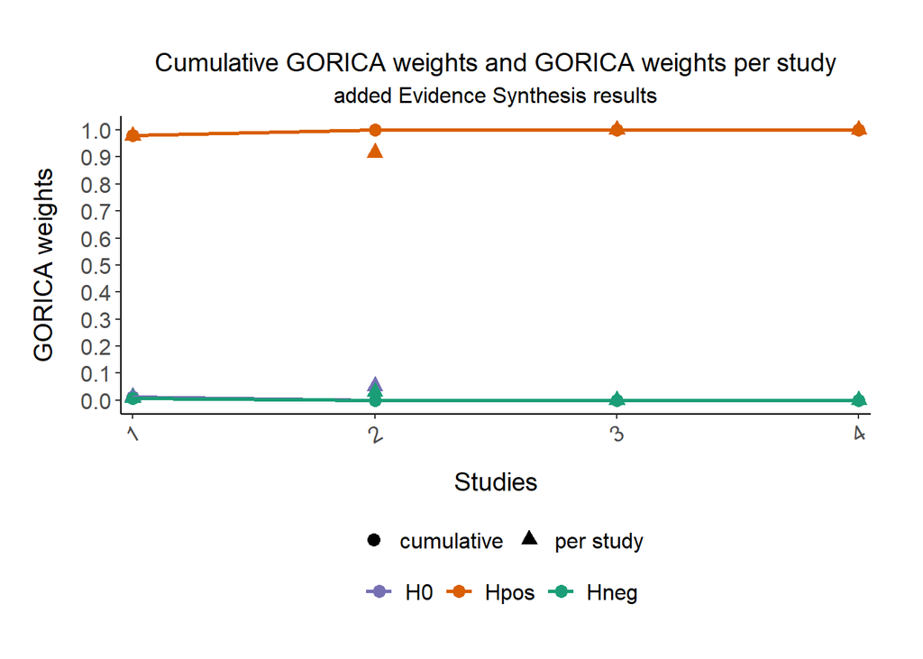

```
# Btw you can also change plot options; like
# - adding study names;
# - make changes to say subtitle or x-axis.
# This will be demonstrated in the next exercise,
# or can be found via the help function: '?evSyn'.
```

```r
# Final ratios of GORICA weights:
#round(evSyn_trust$Final_ratio_GORICA_weights, 2)
# Study-specific and final/overall output:
#summary(evSyn_trust)
# Study-specific GORICA weights:
#evSyn_trust$GORICA_weight_m
# evSyn plot:
plot(evSyn_trust)
```

*Conclusion:*  
Support for Hpos is highest: thus, favor Hpos over H0 and Hneg.  
Hence, previous experience has a positive effect on trust; which receives full support.

# 4 Exercise 4: Aggregating evidence from homogeneous studies

*Intro*

In this exercise, we make use of the ‘metafor’ example ‘Comparing surgical and non-surgical treatments for periodontal disease’, which is based on the study by Berkey and colleagues (1998).

In this study, surgical and non-surgical treatments for medium-severity periodontal disease are compared in five trials (i.e., 5 studies). Two outcomes reflect severity: attachment level (AL) and probing depth (PD) one year after the treatment. Higher attachment levels and lower probing depth are indicators of less severity, and are thus preferred.

The effect sizes to be aggregated are the (raw) mean differences, where non-surgical treatment is the reference category. The outcomes are calculated such that a positive value indicates that surgery was more effective in reducing severity than non-surgical treatment. In summary, a positive estimate indicates effectiveness of surgery in either increasing the attachment level or decreasing the probing depth.

*Data: 5 studies*

First, install and call the `metafor` library to load data from Berkey et al. (1998) and the `restriktor` library to load the `evSyn` function. If needed, it is possible to view the description of the data set and function with the `?` operator or the `help` command.

```r
# To install the packages in R: if (!require('restriktor'))
# install.packages('restriktor')

# To install restriktor from github: if (!require('devtools'))
# install.packages('devtools') library(devtools)
# install_github('LeonardV/restriktor')
library(restriktor)
# print docs in the help-tab to view arguments and explanations for the
# function ?evSyn

# Data if (!require('metafor')) install.packages('metafor')
library(metafor)
dat <- dat.berkey1998
# print docs in the help-tab to view explanations for the data set
# ?dat.berkey1998
```

Let us inspect the `data.frame`.

```r
View(dat)
```

Each `trial` is one study into the comparison of surgical and non-surgical treatments for severity of periodontal disease one year after treatment. Every study contains two rows in the `dat` data.frame, one for probing depth (PD) and one for attachment level (AL).

*Remark data.frame*

In this exercise, a data.frame is thus used as input for ‘evSyn’. If you want more information on how to use a data.frame in ‘evSyn’, you can check:  
- ‘Click to see more information on using a data.frame’ below;  
- ‘Example 2’ in ‘Tutorial_GORIC_restriktor_evSyn’ on https://github.com/rebeccakuiper/Tutorials; and/or  
- The help document of ‘evSyn’, using: ``?evSyn’’.

## 4.1 Exercise 4a: Added-evidence approach

Come up with a central theory, with possibly a competing one. Next, perform added-evidence synthesis on these five studies. Possibly, play around with the plot options: The resulting evSyn plot is a ‘ggplot’ and can be changed as such.

**Click to see which set of informative hypotheses is used in the answers**

One may hypothesize from theory that surgery has a negative effect on attachment level, but a positive effect on probing depth. In each study, this can be reflected by: $H_{-+}: \theta_{AL} < 0; \ \theta_{PD} > 0$, where $\theta$ denotes the difference in means between surgical and non-surgical treatments.

There may also be reason to believe that surgery is too invasive, and thus non-surgery decreases severity on both outcomes compared to surgery: $H_{--}: \theta_{AL} < 0; \ \theta_{PD} < 0$.

In sum, the informative, theory-based hypotheses used in the answer are:  
$H_{-+}: \theta_{AL} < 0; \ \theta_{PD} > 0$ and  
$H_{--}: \theta_{AL} < 0; \ \theta_{PD} < 0$.  
These hypothesis are evaluated against the unconstrained, just to make sure that not a weak hypothesis is chosen as the best.

**Click to see more information on using a data.frame**

If there would be only one (effect size) estimate, one can specify the data.frame as the input without an extra data-argument. When not specifying the data-argument ‘outcome_col’, the function assumes that the parameter of interest is called ‘theta’; as it will also mention. The hypotheses should then thus also that labeling.

In this case, we have two parameters of interest. Since we have the variable ‘outcome’ in our data set (cf. ‘dat$outcome’), we do not need to use the data-argument ‘outcome_col’. Next, I will use code in which we do specify the data-argument ‘outcome_col’. This argument needs the name of the column that contains the outcome names, which then denotes the labels of our parameters of interest. The hypotheses should then be specified using those outcome names (cf. ‘unique(dat$outcome)’.

Here, the column is called ‘outcome’, which contains the names/labels ‘AL’ and ‘PD’ (so, theses should be used in the hypothesis specification).

**Click to see answers**

```r
# Hypotheses
H_neg_pos <- "AL < 0; PD > 0"
H_neg_neg <- "AL < 0; PD < 0"

# Study names #
# Instead of using numbers for the studies, one can also attach names to them.
# Here, the author names will be used, listed in the variable author in the data.frame:
study_names <- dat[dat$outcome=="AL",]$author

# Added-evidence synthesis
results_evSyn_added <- evSyn(object = dat,
                      outcome_col = "outcome", # column with 'AL' & 'PB'
                      hypotheses = list(H_neg_pos = H_neg_pos, H_neg_neg = H_neg_neg),
                      #comparison = "unconstrained" # default
                      #type_ev = "added" # default
                      study_names = study_names
                      )

# Show output
results_evSyn_added
```

```
restriktor (0.7): added Evidence Synthesis results:

Input type 'escalc' detected: Parameter estimates and covariance matrix inherited from escalc object

---

Final log-likelihood (LL) & GORICA weights:
               LL weights  GORICA weights
H_neg_pos           0.500           0.997
H_neg_neg           0.000           0.000
Unconstrained       0.500           0.003

---

Ratio final GORICA weights:
               vs. H_neg_pos  vs. H_neg_neg  vs. Unconstrained
H_neg_pos              1.000       4.95e+34            285.368
H_neg_neg              0.000          1.000              0.000
Unconstrained          0.004       1.74e+32              1.000
```

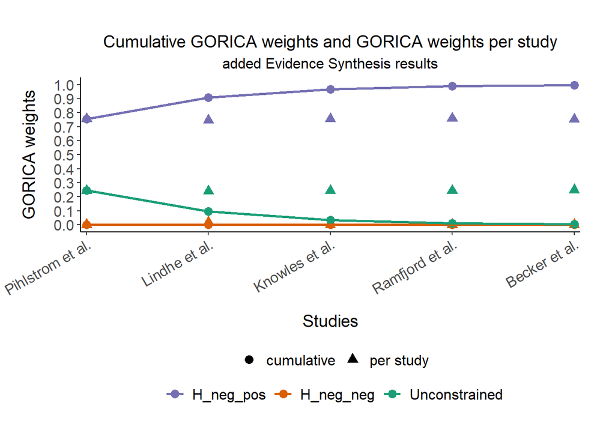

```r
# Final ratios of GORICA weights:
#round(results_evSyn_added$Final_ratio_GORICA_weights, 2)
# Study-specific and final/overall output:
#summary(results_evSyn_added)
# Study-specific GORICA weights:
#results_evSyn_added$GORICA_weight_m
# evSyn plot:
plot(results_evSyn_added)
```

*Conclusion:*

When inspecting the (ratios of) final GORICA weights, one can see that $H_{-+}$ (‘H_neg_pos’) is not weak, since its final GORICA weight is higher than that of the unconstrained (or: their ratio is larger than 1). Furthermore, that it is convincingly preferred over its alternative $H_{--}$ (‘H_neg_neg’): $H_{-+}$ is practically an infinite amount of times more likely than $H_{--}$, given the data.

Therefore, it can be concluded that surgical performance has a positive effect on probing depth, but a negative effect on attachment level.

*Possible follow-up analysis:*

Now, you may also want to investigate $H_{-+}$ (‘H_neg_pos’) against its complement, which may be helpful for future research:

```r
# Study names #
study_names <- dat[dat$outcome=="AL",]$author

# Added-evidence synthesis
results_evSyn_added_H1c <- evSyn(#estimates, VCOV = covmats,
                          object = dat, outcome_col = "outcome",
                          hypotheses = list(H_neg_pos = H_neg_pos),
                          #comparison = 'complement' # default
                          #type_ev = "added" # default
                          study_names = study_names
                          )
```

```
restriktor Message: The data contains multiple variables with a 'cluster_col' name, the following one is used: 'trial'
```

```r
# Show output
results_evSyn_added_H1c
```

```
restriktor (0.7): added Evidence Synthesis results:

Input type 'escalc' detected: Parameter estimates and covariance matrix inherited from escalc object

---

Final log-likelihood (LL) & GORICA weights:
               LL weights  GORICA weights
H_neg_pos           0.500           0.997
Unconstrained       0.500           0.003

---

Ratio final GORICA weights:
               vs. H_neg_pos  vs. Unconstrained
H_neg_pos              1.000            285.368
Unconstrained          0.004              1.000
```

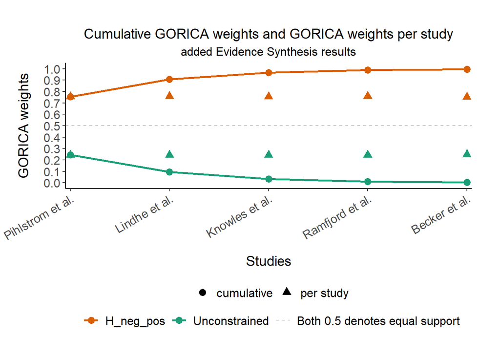

```r
# Final ratios of GORICA weights:
#round(results_evSyn_added_H1c$Final_ratio_GORICA_weights, 2)
# Study-specific and final/overall output:
#summary(results_evSyn_added_H1c)
# Study-specific GORICA weights:
#results_evSyn_added_H1c$GORICA_weight_m
# evSyn plot:
plot(results_evSyn_added_H1c)
```

One can see that $H_{-+}$ is also much more likely than its complement, that is, all other possible hypotheses / theories.

**Click to see some plot options**

The evSyn plot is a ‘ggplot’ and can be changed as such.

As an example, one could change the x-axis colors based on the value(s) of another variable (in a way, looking at subgroups):

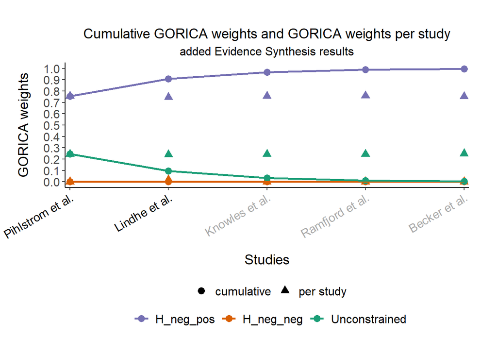

```r
# Change x-axis color # Next, we set the colors based on two subgroups of
# studies, those published before 1983 (dark-gray) and those published that
# year or later (black):
evSynplot <- plot(results_evSyn_added)
cols_subgroup <- ifelse(dat$year < 1983, "darkgray", "black")
library(ggplot2)
evSynplot_subgroup <- evSynplot + theme(axis.text.x = element_text(colour = cols_subgroup))
evSynplot_subgroup
```

As another example, one can overwrite the subtitle:

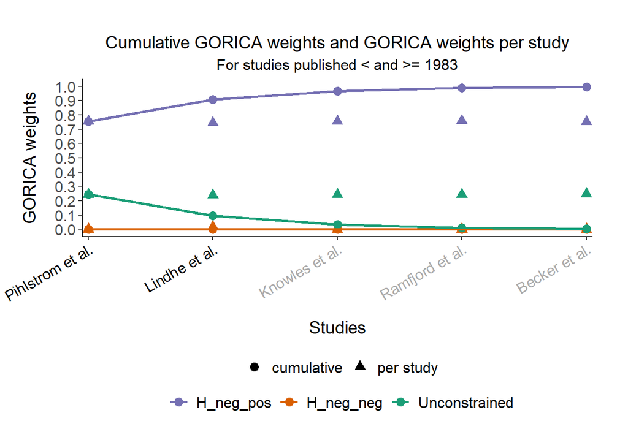

```r
# Change subtitle #
evSynplot_subgroup_subtitle <- evSynplot_subgroup + labs(subtitle = "For studies published < and >= 1983")
evSynplot_subgroup_subtitle
```

## 4.2 Exercise 4b: Leave one study out

Do a leave-one-study-out analysis (using ‘leave1studyout’). Such an analyses denotes whether a study is an influential study / might be an outlier study.

**Click to see answers**

```r
leave1out_evSyn_added <- leave1studyout(results_evSyn_added)
# leave1out_evSyn_added
leave1out_evSyn_added$OverallGoricaWeights
```

```
                                                 H_neg_pos    H_neg_neg Unconstrained
Leave study nr. 1 called 'Pihlstrom et al.' out: 0.9892772 6.431472e-29    0.01072279
Leave study nr. 2 called 'Lindhe et al.' out:    0.9891780 8.799974e-34    0.01082197
Leave study nr. 3 called 'Knowles et al.' out:   0.9892274 9.145317e-19    0.01077259
Leave study nr. 4 called 'Ramfjord et al.' out:  0.9891401 3.058261e-30    0.01085991
Leave study nr. 5 called 'Becker et al.' out:    0.9894763 9.940593e-31    0.01052375
```

*Conclusion:*

In this example, the results are not sensitive to the choice of set of studies: For all configurations, H_neg_pos (i.e., $H_{-+}$) is the best hypothesis (or better: the best central theory), with a similar amount of support.

## 4.3 Exercise 4c: Equal-evidence approach

Until now, we have conducted evidence synthesis using the added-evidence approach. Now, run the equal-evidence approach (using ‘type_ev = “Equal”’).

Notably, such an analysis renders the overall support as if there would be one large study (when it would be possible to combine the datasets).

**Click to see answers**

```r
# Hypotheses
H_neg_pos <- "AL < 0; PD > 0"
H_neg_neg <- "AL < 0; PD < 0"

# Study names #
study_names <- dat[dat$outcome=="AL",]$author

# Equal-evidence synthesis
results_evSyn_equal <- evSyn(object = dat,
                      outcome_col = "outcome", # column with 'AL' & 'PB'
                      hypotheses = list(H_neg_pos = H_neg_pos, H_neg_neg = H_neg_neg),
                      #comparison = "unconstrained" # default
                      type_ev = "equal",
                      study_names = study_names
                      )

# Show output
results_evSyn_equal
```

```
restriktor (0.7): equal Evidence Synthesis results:

Input type 'escalc' detected: Parameter estimates and covariance matrix inherited from escalc object

---

Final log-likelihood (LL) & GORICA weights:
               LL weights  GORICA weights
H_neg_pos           0.500           0.756
H_neg_neg           0.000           0.000
Unconstrained       0.500           0.244

---

Ratio final GORICA weights:
               vs. H_neg_pos  vs. H_neg_neg  vs. Unconstrained
H_neg_pos              1.000       1.74e+34              3.098
H_neg_neg              0.000          1.000              0.000
Unconstrained          0.323       5.62e+33              1.000
```

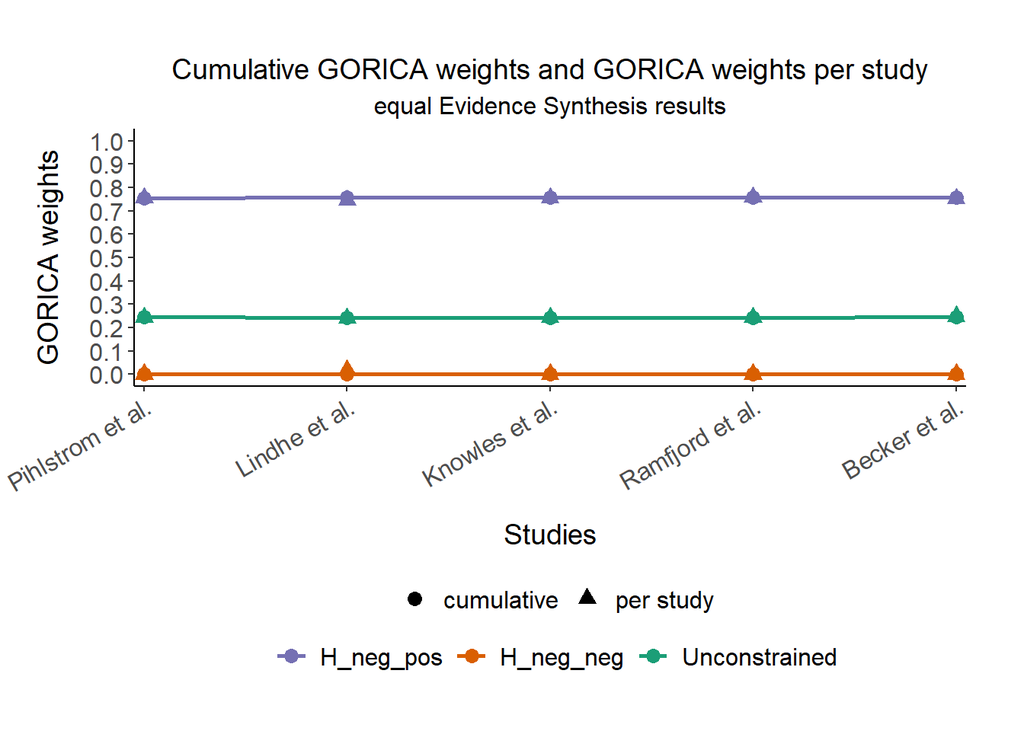

```r
# Final ratios of GORICA weights:
#round(results_evSyn_equal$Final_ratio_GORICA_weights, 2)
# Study-specific and final/overall output:
#summary(results_evSyn_equal)
# Study-specific GORICA weights:
#results_evSyn_equal$GORICA_weight_m
# evSyn plot:
plot(results_evSyn_equal)
```

*Conclusion:*

When inspecting the (ratios of) final GORICA weights, one can see that $H_{-+}$ (‘H_neg_pos’) is not weak, since its final GORICA weight is higher than that of the unconstrained (or: their ratio is larger than 1). Furthermore, that it is convincingly preferred over its alternative $H_{--}$ (‘H_neg_neg’): $H_{-+}$ is practically an infinite amount of times more likely than $H_{--}$, given the data.

Therefore, it can be concluded that surgical performance has a positive effect on probing depth, but a negative effect on attachment level.

Note: The preferred central theory may be the same as for the added-evidence approach, some of the results do differ (cf. GORICA weights). More importantly, the approaches answer different research questions.

*Possible follow-up analysis:*

Now, you may also want to investigate $H_{-+}$ (‘H_neg_pos’) against its complement, which may be helpful for future research:

```r
# Study names #
study_names <- dat[dat$outcome=="AL",]$author

# Added-evidence synthesis
results_evSyn_equal_H1c <- evSyn(#estimates, VCOV = covmats,
                          object = dat, outcome_col = "outcome",
                          hypotheses = list(H_neg_pos = H_neg_pos),
                          #comparison = 'complement' # default
                          type_ev = "equal",
                          study_names = study_names
                          )
```

```
restriktor Message: The data contains multiple variables with a 'cluster_col' name, the following one is used: 'trial'
```

```r
# Show output
results_evSyn_equal_H1c
```

```
restriktor (0.7): equal Evidence Synthesis results:

Input type 'escalc' detected: Parameter estimates and covariance matrix inherited from escalc object

---

Final log-likelihood (LL) & GORICA weights:
               LL weights  GORICA weights
H_neg_pos           0.500           0.756
Unconstrained       0.500           0.244

---

Ratio final GORICA weights:
               vs. H_neg_pos  vs. Unconstrained
H_neg_pos              1.000              3.098
Unconstrained          0.323              1.000
```

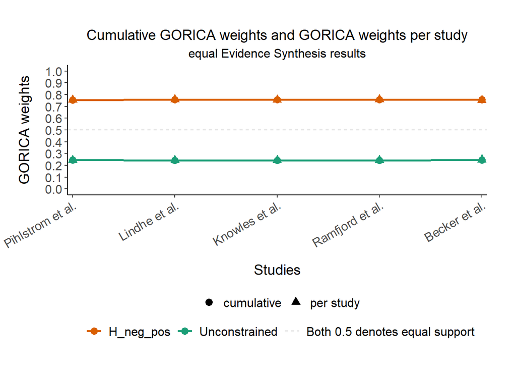

```r
# Final ratios of GORICA weights:
#round(results_evSyn_equal_H1c$Final_ratio_GORICA_weights, 2)
# Study-specific and final/overall output:
#summary(results_evSyn_equal_H1c)
# Study-specific GORICA weights:
#results_evSyn_equal_H1c$GORICA_weight_m
# evSyn plot:
plot(results_evSyn_equal_H1c)
```

One can see that $H_{-+}$ is also much more likely than its complement, that is, all other possible hypotheses / theories.

## 4.4 Exercise 4d (Extra): GORICA on meta-analysis estimates

Instead of doing evidence synthesis, one can in this case (nl., studies with homogeneous designs / comparable estimates) also perform a meta-analysis and subsequently evaluate the central theories using the GORICA.

Do a meta-analysis (using ‘rma.mv’ from ‘metafor’) and evaluate the central theories you used in the sub-exercises above. For the latter, you need the `goric` function (from the `restriktor` package), and you can use the `metafor` object as input (but you could also extract the estimates of interest and their covariance matrix from the `metafor` object and use those, where you possibly want to re-label the estimate names).

**Click to see the metafor code used in the answers**

```r
# if (!require('metafor')) install.packages('metafor')
library(metafor)

# Construct the full (block-diagonal) variance-covariance for all studies:
V <- vcalc(vi = 1, cluster = author, rvars = c(v1i, v2i), data = dat)

# Run a multivariate model to meta-analyze the two outcomes simultaneously:
res_metaan <- rma.mv(yi, V, mods = ~0 + outcome, data = dat, method = "ML")
print(res_metaan, digits = 3)
```

```
Multivariate Meta-Analysis Model (k = 10; method: ML)

Variance Components: none

Test for Residual Heterogeneity:
QE(df = 8) = 128.227, p-val < .001

Test of Moderators (coefficients 1:2):
QM(df = 2) = 871.319, p-val < .001

Model Results:

           estimate     se     zval   pval   ci.lb   ci.ub
outcomeAL    -0.394  0.019  -21.147  <.001  -0.431  -0.358  ***
outcomePD     0.307  0.029   10.751  <.001   0.251   0.363  ***

---
Signif. codes:  0 '***' 0.001 '**' 0.01 '*' 0.05 '.' 0.1 ' ' 1
```

```r
# Note When looking at the forest plot, you can also see the mixed results from
# these studies: forest(res_metaan)
```

Note: The GORICA can also be applied to random-effects and mixed-effects models, but in the answers I use the fixed-effects model.

**Click to see the parameter names in case of using the metafor object**

```r
# Check names of the overall estimates, these need to be used in the hypothesis
# specification:
names(coef(res_metaan))
```

```
[1] "outcomeAL" "outcomePD"
```

**Click to see answers**

```r
#if (!require("metafor")) install.packages("metafor")
library(metafor)

#Construct the full (block-diagonal) variance-covariance for all studies:
V <- vcalc(vi=1, cluster=author, rvars=c(v1i, v2i), data=dat)

# Run a multivariate model to meta-analyze the two outcomes simultaneously:
res_metaan <- rma.mv(yi, V, mods = ~ 0 + outcome,
                     data = dat, method = "ML")
print(res_metaan, digits=3)
```

```
Multivariate Meta-Analysis Model (k = 10; method: ML)

Variance Components: none

Test for Residual Heterogeneity:
QE(df = 8) = 128.227, p-val < .001

Test of Moderators (coefficients 1:2):
QM(df = 2) = 871.319, p-val < .001

Model Results:

           estimate     se     zval   pval   ci.lb   ci.ub
outcomeAL    -0.394  0.019  -21.147  <.001  -0.431  -0.358  ***
outcomePD     0.307  0.029   10.751  <.001   0.251   0.363  ***

---
Signif. codes:  0 '***' 0.001 '**' 0.01 '*' 0.05 '.' 0.1 ' ' 1
```

```r
# Check names of the overall estimates,
# these need to be used in the hypothesis specification:
names(coef(res_metaan))
```

```
[1] "outcomeAL" "outcomePD"
```

```r
# Hypotheses
H_neg_pos <- "outcomeAL < 0; outcomePD > 0"
H_neg_neg <- "outcomeAL < 0; outcomePD < 0"

# GORICA on meta-analyzed, overall estimates
results_metaan_GORICA <- goric(res_metaan,
                               hypotheses = list(H_neg_pos = H_neg_pos,
                                                 H_neg_neg = H_neg_neg)
                               #comparison = "unconstrained" # default
                               #type = "gorica" # default
                               )

# Show output
results_metaan_GORICA
```

```
restriktor (0.7): generalized order-restricted information criterion approximation:

Results:
           model   loglik  penalty   gorica  loglik.weights  penalty.weights  gorica.weights  gorica.weights_without_unc
1      H_neg_pos    5.781    0.873   -9.817           0.500            0.476           0.755                       1.000
2      H_neg_neg  -52.013    1.127  106.281           0.000            0.369           0.000                       0.000
3  unconstrained    5.781    2.000   -7.562           0.500            0.154           0.245

Conclusion:
- The order-restricted hypothesis 'H_neg_pos' is the best in the set, as it has the highest GORIC(A) weight.
- Since 'H_neg_pos' has a higher GORIC(A) weight than the unconstrained hypothesis, it is not considered weak. We can now inspect the relative support for 'H_neg_pos' against the other order-restricted hypotheses:
  * 'H_neg_pos' is 1.623e+25 times more supported than 'H_neg_neg'.
```

```r
round(results_metaan_GORICA$ratio.gw, 2)
```

```
                 vs. H_neg_pos vs. H_neg_neg vs. unconstrained
H_neg_pos (best)          1.00  1.623032e+25              3.09
H_neg_neg                 0.00  1.000000e+00              0.00
unconstrained             0.32  5.258068e+24              1.00
```

```r
#sprintf("%.2e", results_metaan_GORICA$ratio.gw)
#summary(results_metaan_GORICA)
```

*Conclusion:*

When inspecting the (ratios of) GORICA weights, one can see that $H_{-+}$ (‘H_neg_pos’) is not weak, since its GORICA weight is higher than that of the unconstrained (or: their ratio is larger than 1). Furthermore, that it is convincingly preferred over its alternative $H_{--}$ (‘H_neg_neg’).

More precise, based on the overall, meta-analyzed estimates, it is most likely that $H_{-+}$ is correct.

Therefore, it can be concluded that surgical performance has a positive effect on probing depth, but a negative effect on attachment level.

Note: The results for the GORICA on the meta-analysis (cf. GORICA weights) closely resemble that of the equal-evidence synthesis; which is to be expected in general when the study sample sizes are not too low.

*Possible follow-up analysis:*

Now, you may also want to investigate $H_{-+}$ (‘H_neg_pos’) against its complement, which may be helpful for future research:

```r
# GORICA on meta-analyzed, overall estimates
results_metaan_GORICA_H1c <- goric(res_metaan,
                                   hypotheses = list(H_neg_pos = H_neg_pos)
                                   #comparison = "complement" # default
                                   #type = "gorica" # default
                                   )
```

```
restriktor Message: The covariance matrix of the estimates was obtained via 'vcov()'. This is the biased (restricted) sample covariance matrix, not the unbiased version based on the total sample size ('N').
```

```r
# Show output
results_metaan_GORICA_H1c
```

```
restriktor (0.7): generalized order-restricted information criterion approximation:

Results:
        model   loglik  penalty   gorica  loglik.weights  penalty.weights  gorica.weights
1   H_neg_pos    5.781    0.873   -9.817           1.000            0.680           1.000
2  complement  -52.013    1.627  107.281           0.000            0.320           0.000

Conclusion:
The order-restricted hypothesis 'H_neg_pos' has 2.68e+25 times more support than its complement.
```

```r
# summary(results_metaan_GORICA_H1c)
```

One can see that $H_{-+}$ is also much more likely than its complement, that is, all other possible hypotheses / theories.

# 5 Exercise 5 (Optional): Work on your own or other data

Do one or more of the sub-exercises below.

Notably, when doing evidence synthesis, you should think of the following:

- Hypotheses:
  - What is the central theory/hypothesis?
  - Is there one or more competing ones (and do I need a failsafe hypothesis)?
  - How should the hypotheses be specified in each study?
- Do I want the equal- or added-evidence approach?
- How should I interpret the results?
- Do I want a post-hoc / follow-up analysis? E.g.:
  - Evaluate best hypothesis versus its complement, as input for future research.
  - In case the ‘complement’ or ‘unconstrained’ is the best: An exploratory set-up, evaluating many hypotheses, to generate a (competing) hypothesis for future research.
- Are there influential studies (found by ‘leave1studyout’) and should that/those be discarded or not?

## 5.1 Exercise 5a: Own data

In case you have multiple data sets or multiple primary studies investigating the same central theory/-ies, perform GORIC(A) evidence synthesis to quantify the overall support.

## 5.2 Exercise 5b: ‘metafor’ datasets

Alternatively, you could check out (other) datasets from ‘metafor’ (cf. https://www.metafor-project.org/doku.php/analyses) and perform GORIC(A) evidence synthesis on (one of) those.

Notably, many if not all datasets are data.frame’s, which can be used as input for ‘evSyn’. If you want more information on how to use a data.frame in ‘evSyn’, you can check:  
- Exercise 4;  
- ‘Example 2’ in ‘Tutorial_GORIC_restriktor_evSyn’ on https://github.com/rebeccakuiper/Tutorials; and/or  
- The help document of ‘evSyn’, using: ``?evSyn’’.

## 5.3 Exercise 5c: Studies using different subpopulations

Perform GORIC(A) evidence synthesis using the files in the subfolder ‘Example corona GGD’ in ‘Examples evSyn’ folder on https://github.com/rebeccakuiper/Tutorials.

## 5.4 Exercise 5d: Many heterogeneous and homogeneous studies

Perform GORIC(A) evidence synthesis using the files in the subfolder ‘Example WtC’ in ‘Examples evSyn’ folder on https://github.com/rebeccakuiper/Tutorials.